# State MSM Profile: **North Carolina**

### Background & Methods

In 2015-2016, researchers at Emory University partnered with colleagues at the Centers for Disease Control and Prevention (CDC) to develop methods to estimate the number of men who have sex with men (MSM) residing in each county in the United States. Using population and housing data from the [American Community Survey](https://www.census.gov/programs-surveys/acs/) and estimates from two peer-reviewed publications ([Oster et al., 2015](http://www.ncbi.nlm.nih.gov/pubmed/26115985) & [Purcell et al., 2012](http://www.ncbi.nlm.nih.gov/pubmed/23049658)), they derived an indirect estimate of MSM population sizes that took into account both the urbanicity of the county as well as its density of households with a male householder and a male same-sex partner.

The full methodology is published in the *Journal of Medical Internet Research - Public Health and Surveillance*:

> [Grey JA, Bernstein KT, Sullivan PS, Purcell DW, Chesson HW, Gift TL, Rosenberg ES. Estimating the population sizes of men who have sex with men in US states and counties using data from the American Community Survey. JMIR Public Health Surveill 2016;2(1):e14. DOI: 10.2196/publichealth.5365](http://publichealth.jmir.org/2016/1/e14/)

### Overview of MSM in North Carolina

An estimated **103,009** men who have sex with men (MSM) resided in North Carolina in 2013, representing 2.3% of the 4,503,084 MSM in the United States. Of the 3,536,017 adult men of North Carolina, 2.9% had had sex with another man in the past 5 years, which was less than the overall percentage of adult men in the United States who were MSM (3.9%).

Most MSM in North Carolina resided in central counties of large metropolitan areas (38.8%). Including both central and fringe counties, 51.6% resided in a large metropolitan area.

##### **Percentage of MSM by urbanicity, United States and North Carolina, 2013**

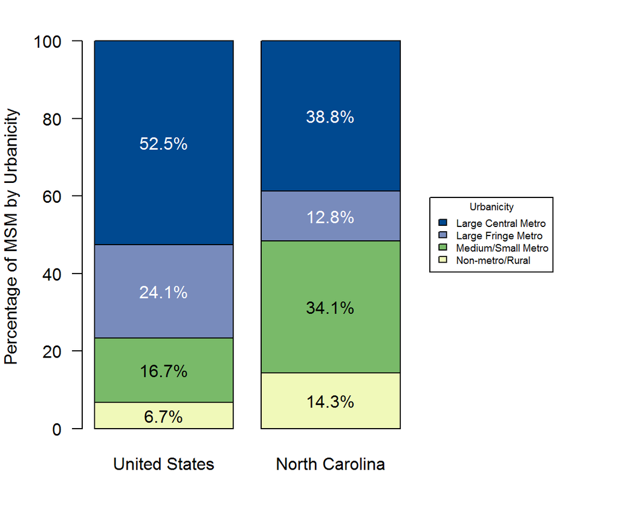

### MSM in North Carolina Counties

Among counties or county-equivalent areas in North Carolina, Mecklenburg County had the largest population of MSM at 20,920, representing 20.3% of all MSM in the state. Swain County had the highest percentage of MSM among adult men in North Carolina at 10.1%. This was greater than the percentage for North Carolina as a whole, which was 2.9% of adult men.

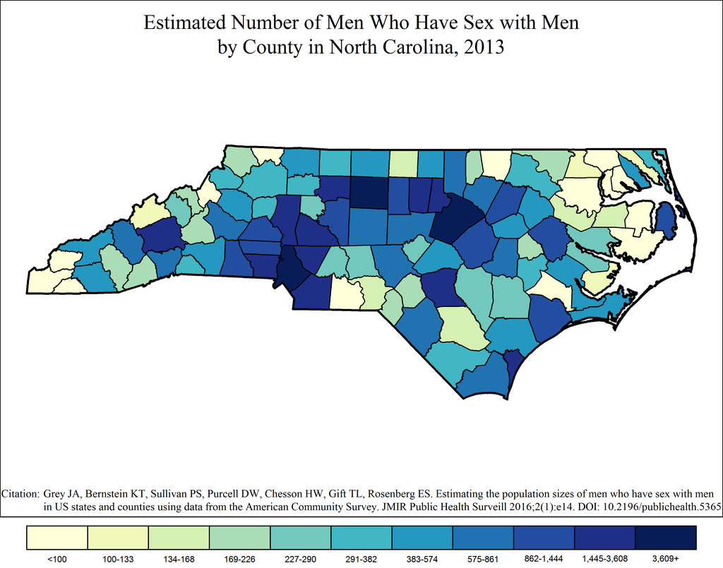

Note: Range cutpoints for the map are based on the distribution of MSM among all counties in the United States.

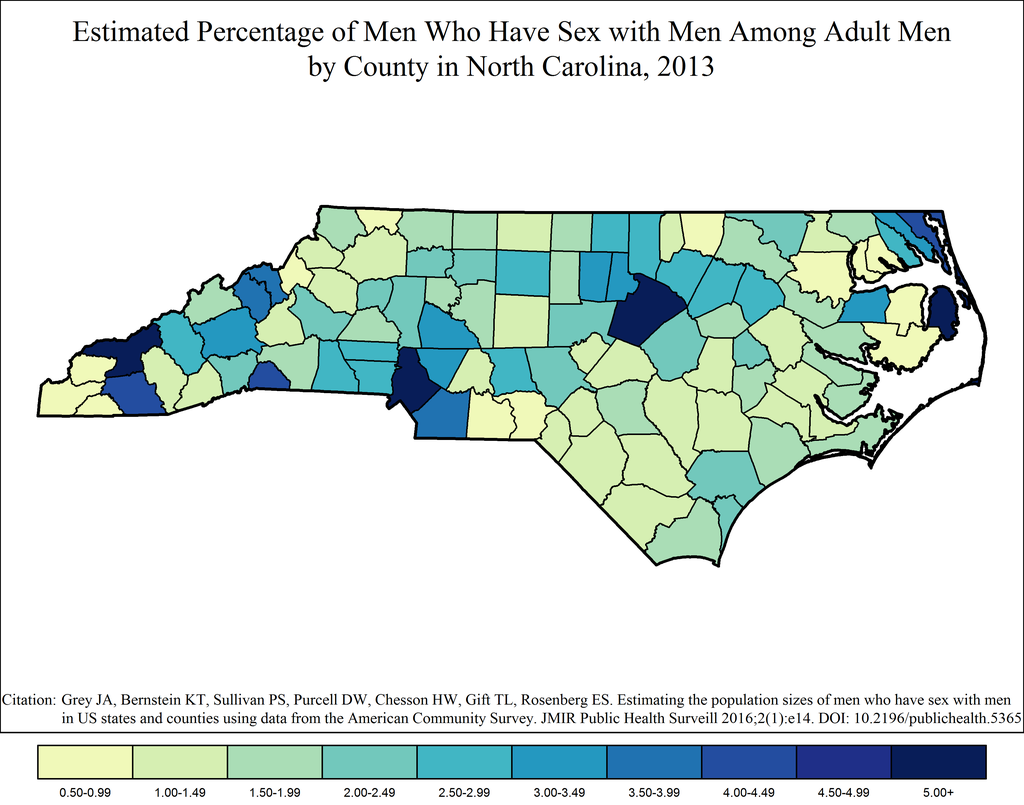

### MSM in North Carolina Metropolitan Statistical Areas

#### Charlotte-Concord-Gastonia Metropolitan Statistical Area

The Charlotte-Concord-Gastonia MSA overlaps two states: North Carolina and South Carolina. The North Carolina portion of the MSA had the largest metropolitan population of MSM in North Carolina at 31,581, or 30.7% of all MSM in the state and 89.0% of the 35,470 MSM in the MSA. Of the 685,029 adult men in the North Carolina part of Charlotte-Concord-Gastonia, an estimated 4.6% were MSM. This was greater than the percentage of MSM among adult men in the MSA as a whole, which was 4.4% of adult men (35,470 out of 807,928).

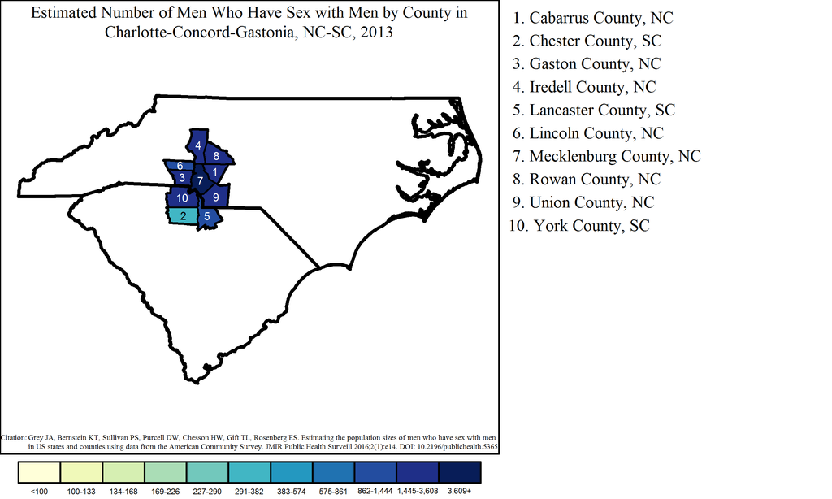

Note: Range cutpoints for the map are based on the distribution of MSM among all counties in the United States.

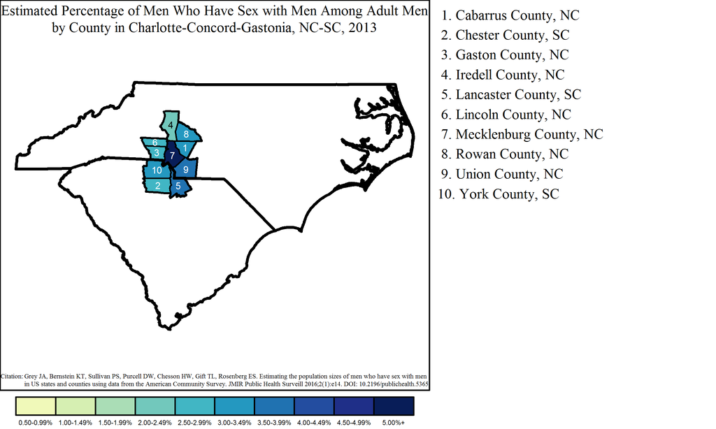

#### Raleigh Metropolitan Statistical Area

The Raleigh MSA had a population of 21,098 MSM, or 20.5% of all MSM in North Carolina. Of the 414,534 adult men in Raleigh, an estimated 5.1% were MSM.

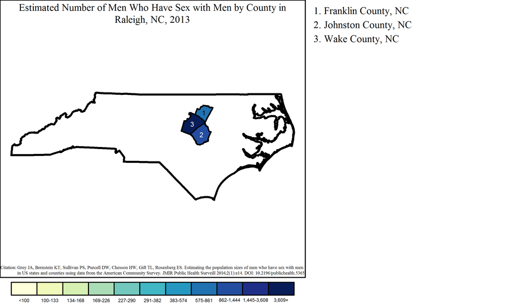

Note: Range cutpoints for the map are based on the distribution of MSM among all counties in the United States.

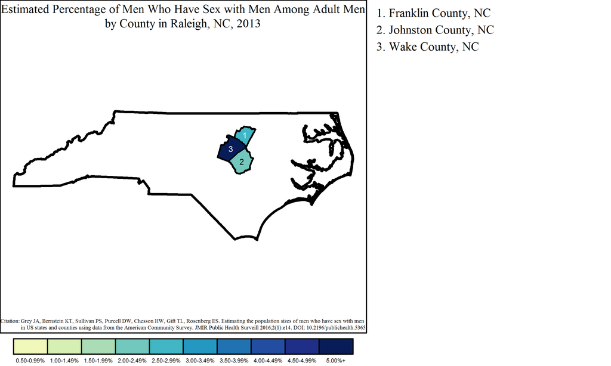

#### Durham-Chapel Hill Metropolitan Statistical Area

The Durham-Chapel Hill MSA had a population of 6,189 MSM, or 6.0% of all MSM in North Carolina. Of the 190,788 adult men in Durham-Chapel Hill, an estimated 3.2% were MSM.

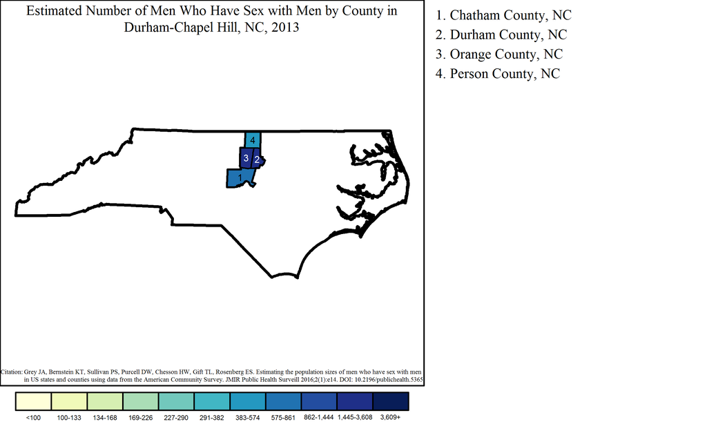

Note: Range cutpoints for the map are based on the distribution of MSM among all counties in the United States.

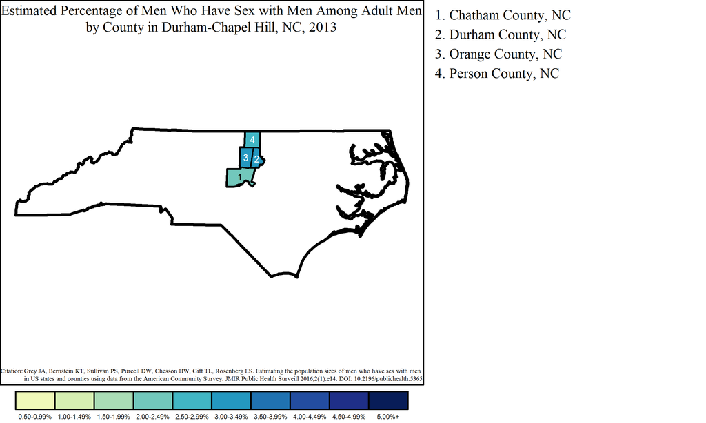

#### Greensboro-High Point Metropolitan Statistical Area

The Greensboro-High Point MSA had a population of 5,974 MSM, or 5.8% of all MSM in North Carolina. Of the 263,850 adult men in Greensboro-High Point, an estimated 2.3% were MSM.

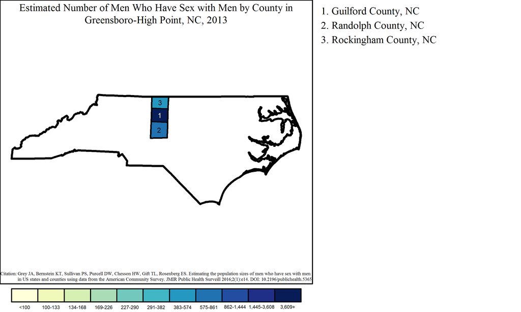

Note: Range cutpoints for the map are based on the distribution of MSM among all counties in the United States.

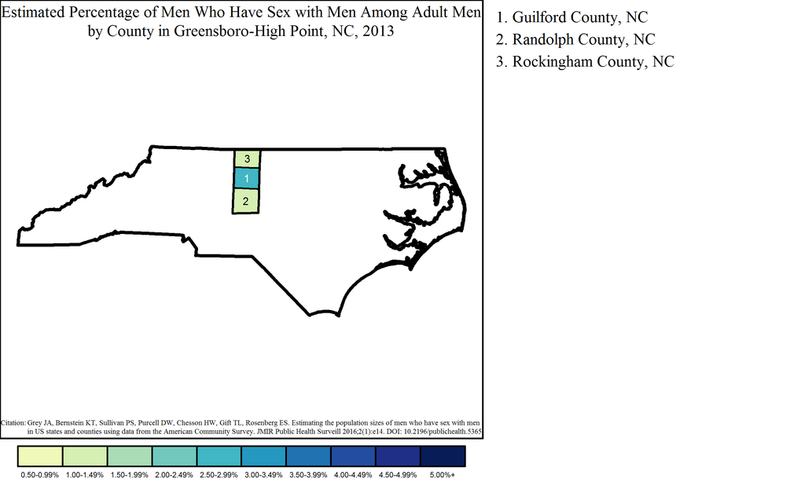

#### Winston-Salem Metropolitan Statistical Area

The Winston-Salem MSA had a population of 4,845 MSM, or 4.7% of all MSM in North Carolina. Of the 232,502 adult men in Winston-Salem, an estimated 2.1% were MSM.

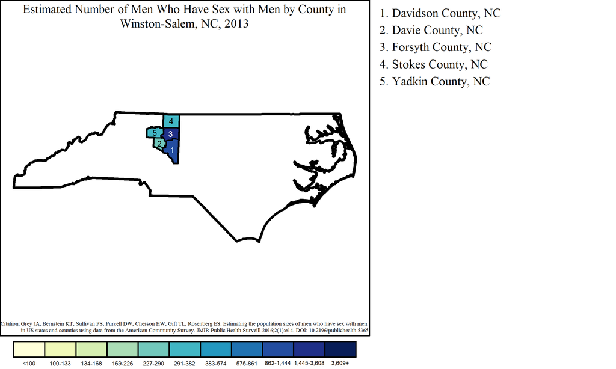

Note: Range cutpoints for the map are based on the distribution of MSM among all counties in the United States.

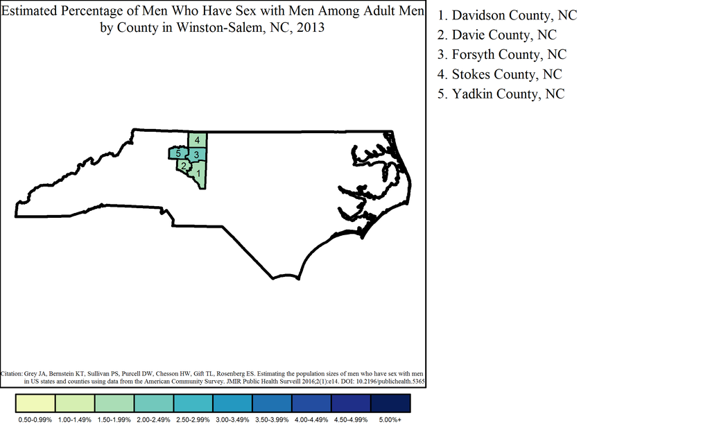

#### Asheville Metropolitan Statistical Area

The Asheville MSA had a population of 4,475 MSM, or 4.3% of all MSM in North Carolina. Of the 163,014 adult men in Asheville, an estimated 2.7% were MSM.

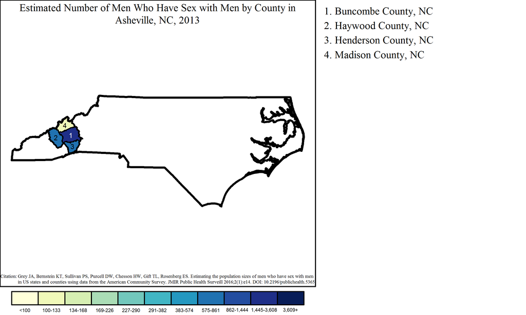

Note: Range cutpoints for the map are based on the distribution of MSM among all counties in the United States.

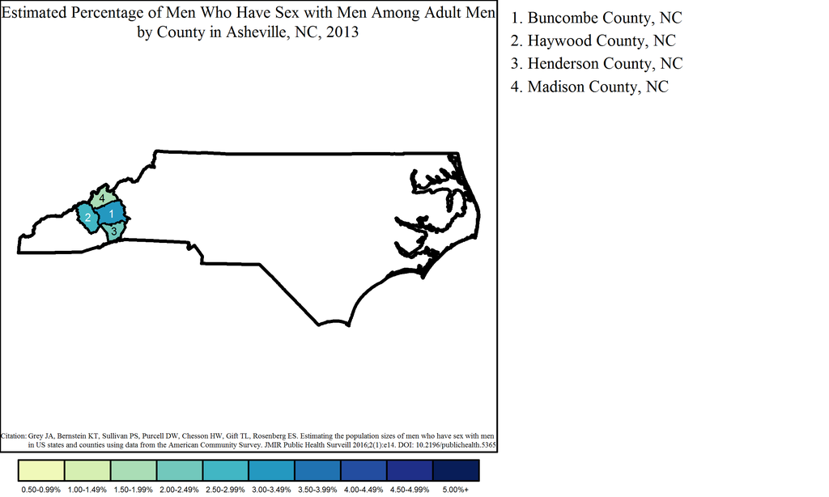

#### Hickory-Lenoir-Morganton Metropolitan Statistical Area

The Hickory-Lenoir-Morganton MSA had a population of 2,607 MSM, or 2.5% of all MSM in North Carolina. Of the 137,891 adult men in Hickory-Lenoir-Morganton, an estimated 1.9% were MSM.

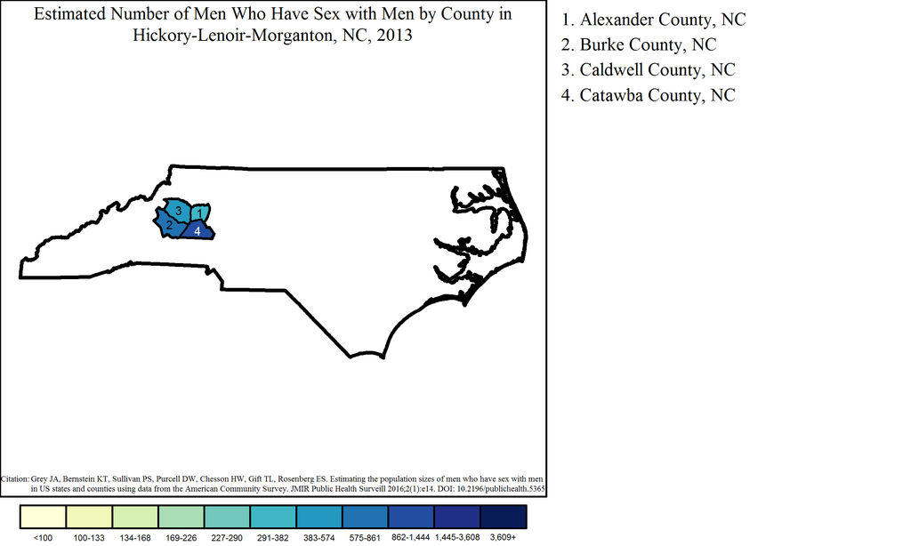

Note: Range cutpoints for the map are based on the distribution of MSM among all counties in the United States.

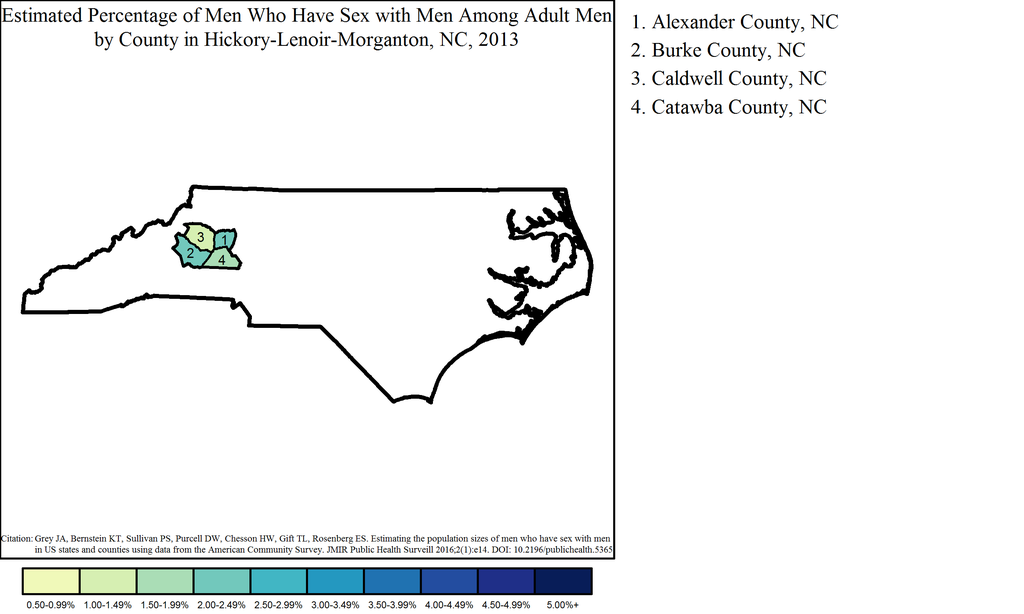

#### Wilmington Metropolitan Statistical Area

The Wilmington MSA had a population of 2,331 MSM, or 2.3% of all MSM in North Carolina. Of the 99,606 adult men in Wilmington, an estimated 2.3% were MSM.

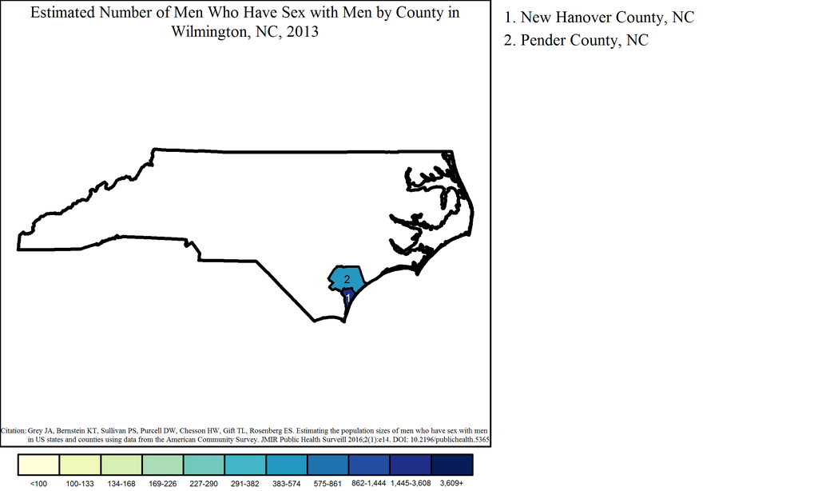

Note: Range cutpoints for the map are based on the distribution of MSM among all counties in the United States.

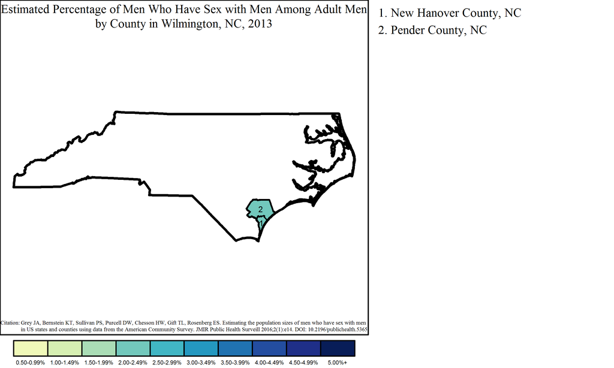

#### Fayetteville Metropolitan Statistical Area

The Fayetteville MSA had a population of 2,024 MSM, or 2.0% of all MSM in North Carolina. Of the 129,585 adult men in Fayetteville, an estimated 1.6% were MSM.

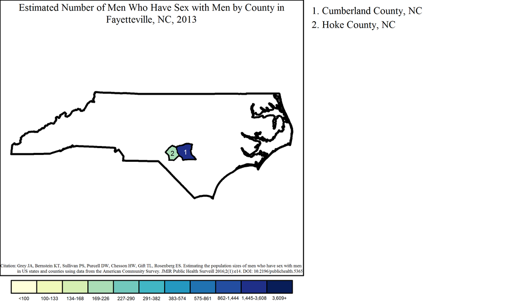

Note: Range cutpoints for the map are based on the distribution of MSM among all counties in the United States.

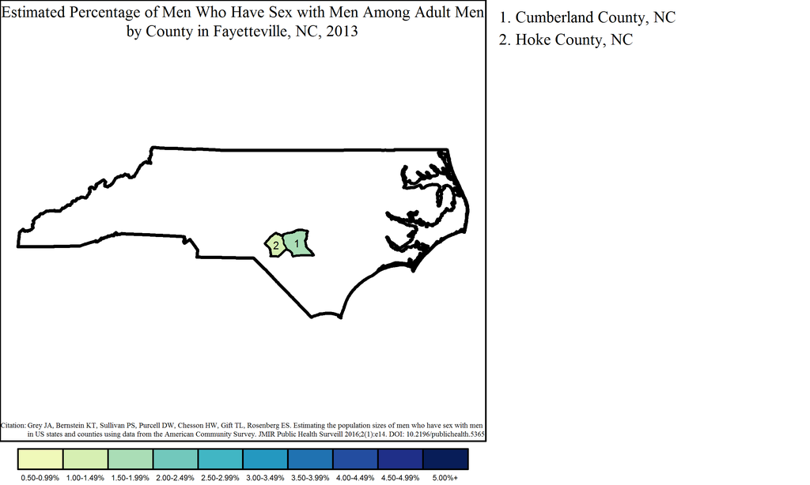

#### Rocky Mount Metropolitan Statistical Area

The Rocky Mount MSA had a population of 1,444 MSM, or 1.4% of all MSM in North Carolina. Of the 53,537 adult men in Rocky Mount, an estimated 2.7% were MSM.

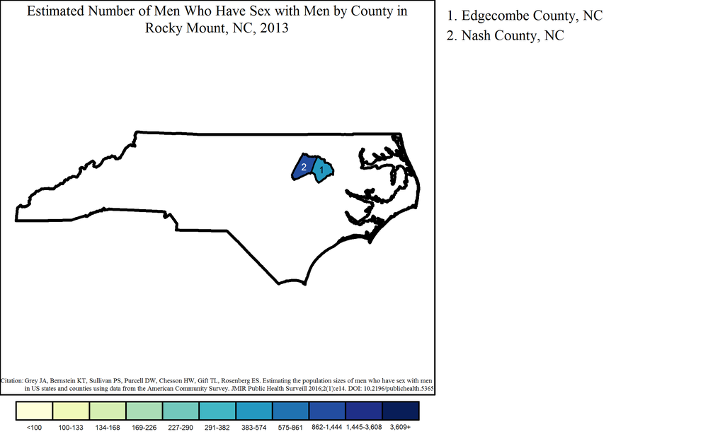

Note: Range cutpoints for the map are based on the distribution of MSM among all counties in the United States.

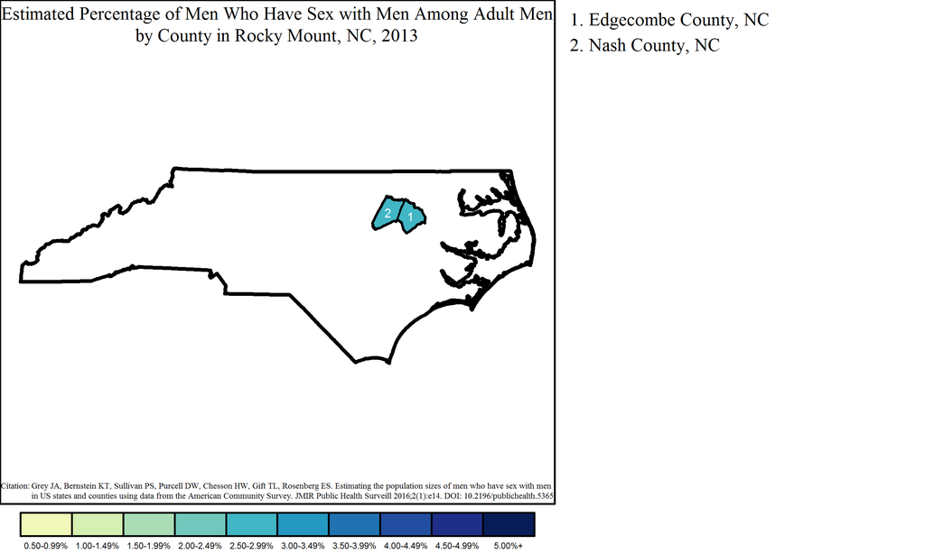

#### Jacksonville Metropolitan Statistical Area

The Jacksonville MSA had a population of 1,127 MSM, or 1.1% of all MSM in North Carolina. Of the 73,672 adult men in Jacksonville, an estimated 1.5% were MSM.

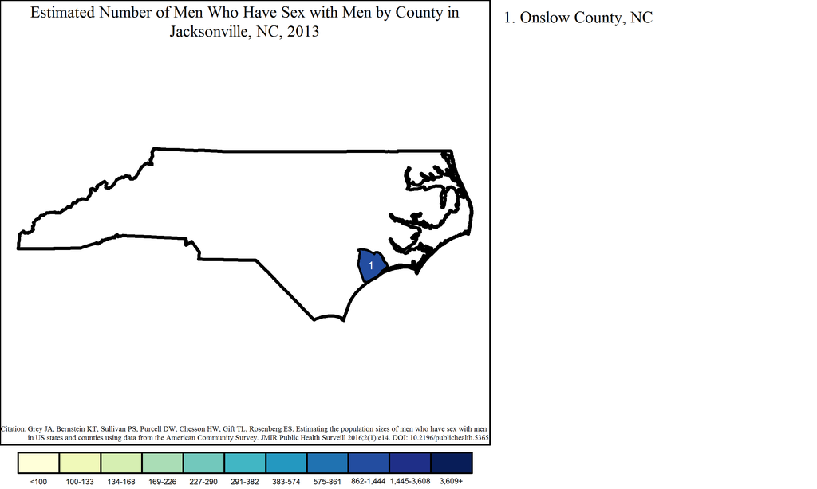

Note: Range cutpoints for the map are based on the distribution of MSM among all counties in the United States.

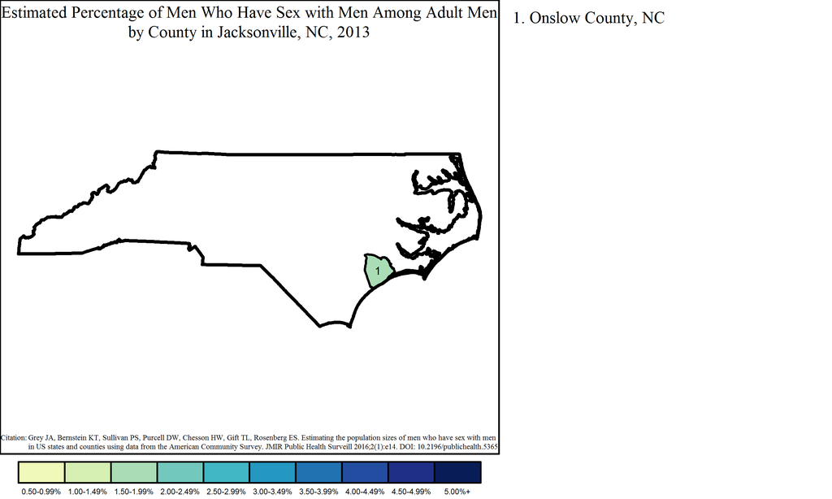

#### Burlington Metropolitan Statistical Area

The Burlington MSA had a population of 1,025 MSM, or 1.0% of all MSM in North Carolina. Of the 54,514 adult men in Burlington, an estimated 1.9% were MSM.

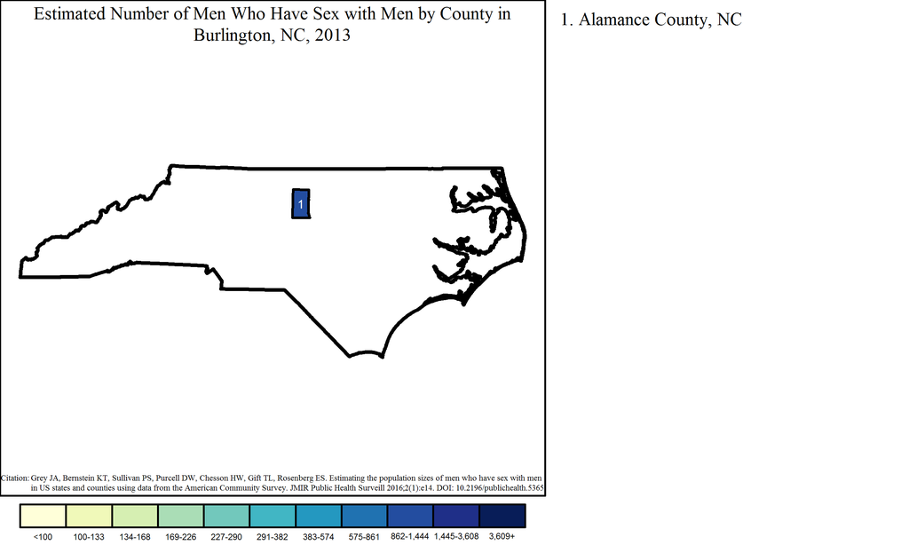

Note: Range cutpoints for the map are based on the distribution of MSM among all counties in the United States.

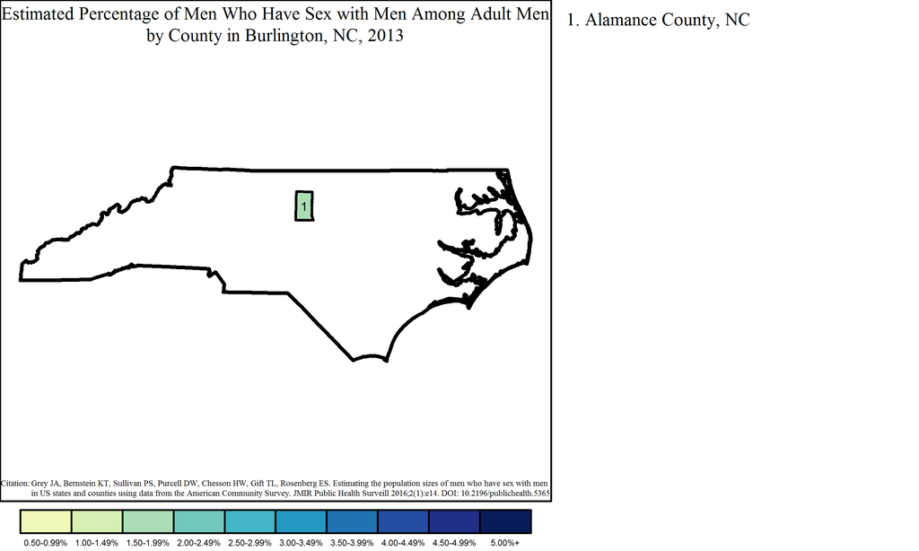

#### Greenville Metropolitan Statistical Area

The Greenville MSA had a population of 870 MSM, or 0.8% of all MSM in North Carolina. Of the 60,926 adult men in Greenville, an estimated 1.4% were MSM.

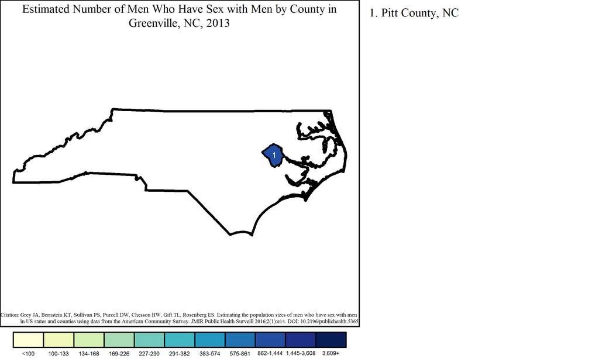

Note: Range cutpoints for the map are based on the distribution of MSM among all counties in the United States.

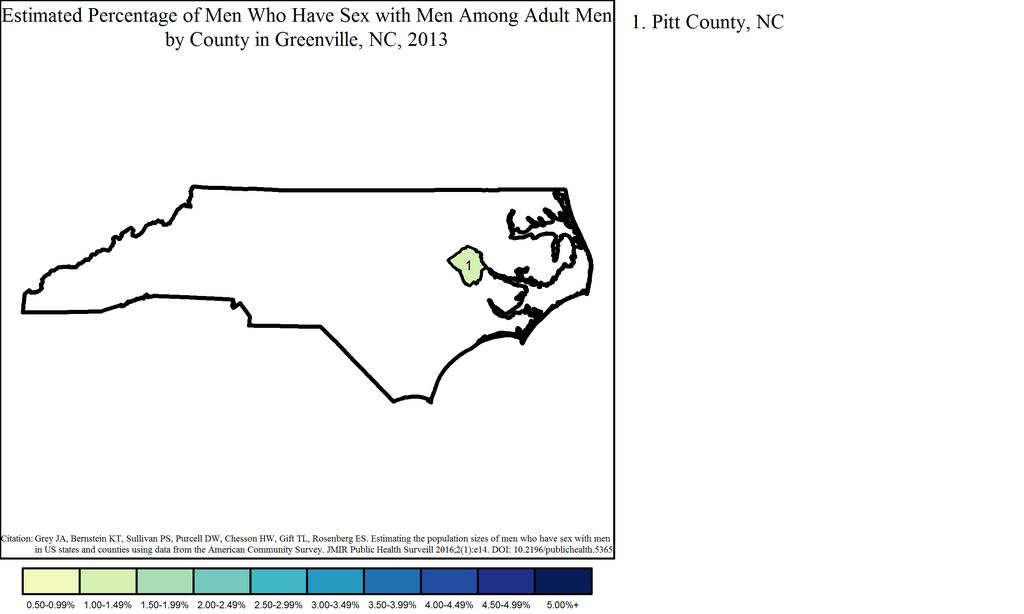

#### Myrtle Beach-Conway-North Myrtle Beach Metropolitan Statistical Area

The Myrtle Beach-Conway-North Myrtle Beach MSA overlaps two states: North Carolina and South Carolina. The North Carolina portion of the MSA had 840 MSM, or 0.8% of all MSM in the state and 27.8% of the 3,018 MSM in the MSA. Of 43,386 adult men in the North Carolina part of Myrtle Beach-Conway-North Myrtle Beach, 1.9% were MSM. This was less than the overall percentage of MSM among adult men in the MSA, which was 2.0% of adult men (3,018 out of 150,218).

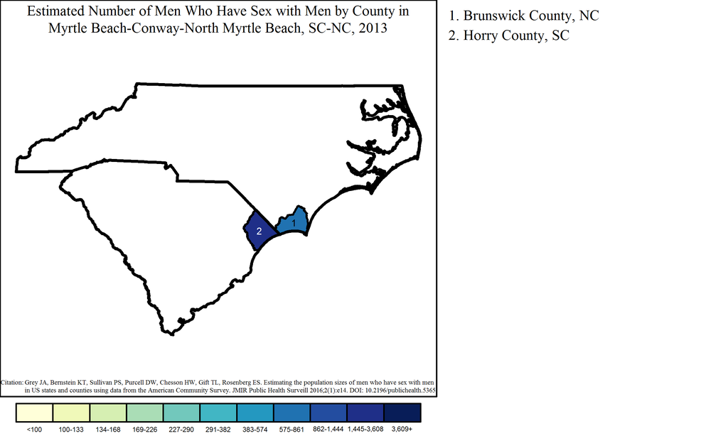

Note: Range cutpoints for the map are based on the distribution of MSM among all counties in the United States.

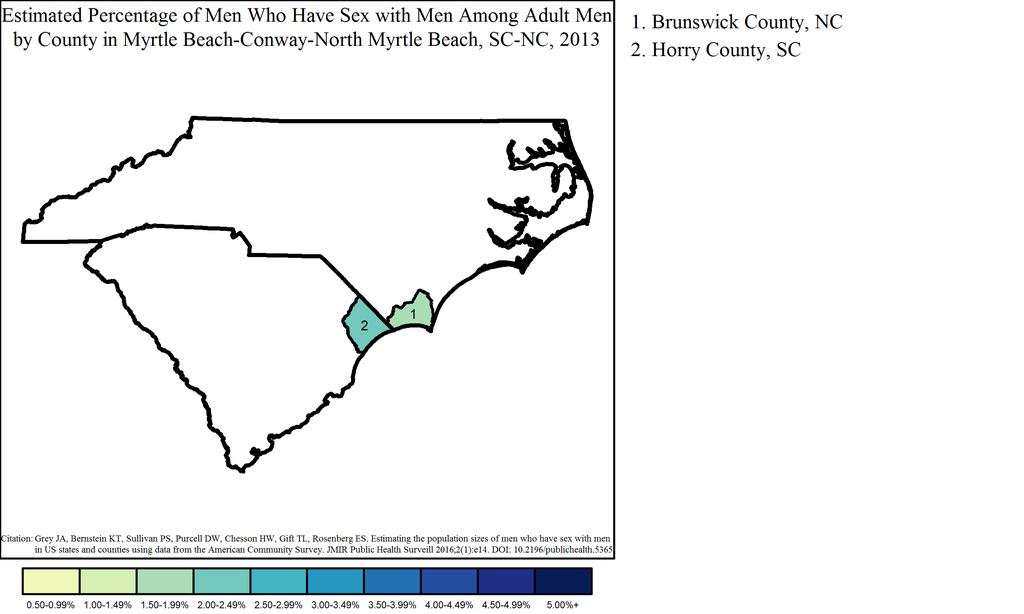